# Spatial data in R: Using R as a GIS

### Plotting raster data

Different plotting functions:

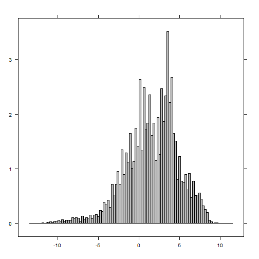

```r
histogram(tmin1.c)
```

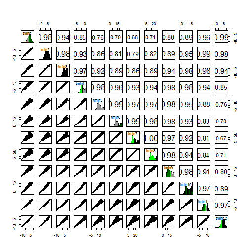

```r
pairs(tmin.all.c)
```

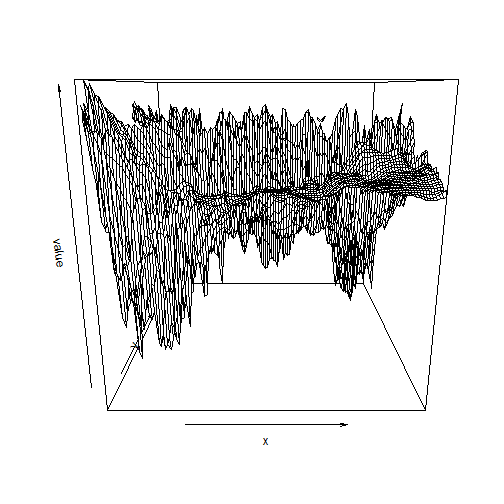

```r
persp(tmin1.c)
```

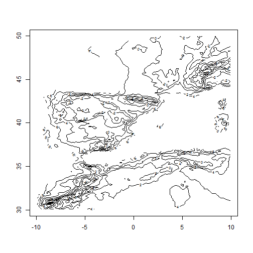

```r
contour(tmin1.c)
```

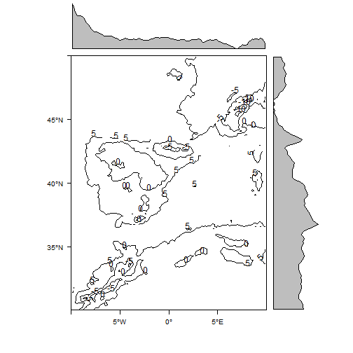

```r
contourplot(tmin1.c)
```

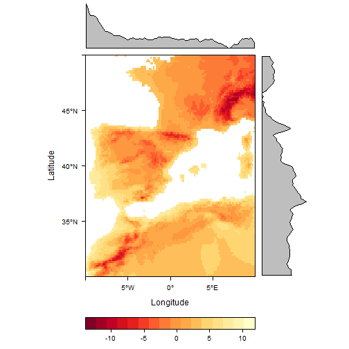

```r
levelplot(tmin1.c)
```

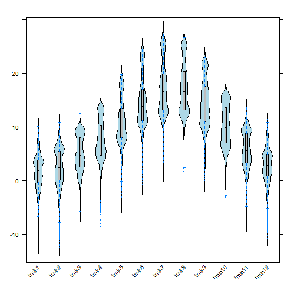

```r
# plot3D(tmin1.c)
bwplot(tmin.all.c)
```

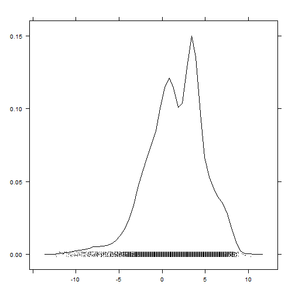

```r
densityplot(tmin1.c)
```

### Spatial autocorrelation

```r
Moran(tmin1.c)  # global Moran's I
```

```
## [1] 0.9099
```

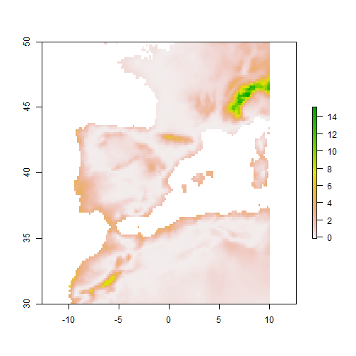

```r
tmin1.Moran <- MoranLocal(tmin1.c)
plot(tmin1.Moran)
```

### Extract values from raster

Use `extract` function:

```r
head(locs)  # we'll obtain tmin values for our points
```

```
##   country
## 1   Spain
## 2   Spain
## 3   Spain
## 4   Spain
## 5   Spain
## 6   Spain
```

```r
projection(tmin1) <- crs.geo
locs$tmin1 <- extract(tmin1, locs)  # raster values
# are incorporated to the dataframe
head(locs)
```

```
##   country tmin1
## 1   Spain   6.7
## 2   Spain   2.1
## 3   Spain   6.7
## 4   Spain   4.2
## 5   Spain   6.2
## 6   Spain   6.7
```

You can also extract values for a given region instead of the whole raster:

```r
plot(tmin1.c)
reg.clim <- extract(tmin1.c, drawExtent())  # click twice to
# draw extent of the region of interest
summary(reg.clim)
```

Using `rasterToPoints`:

```r
# rasterToPoints
tminvals <- rasterToPoints(tmin1.c)
head(tminvals)
```

```
##            x     y tmin1
## [1,] -6.4167 49.92   4.2
## [2,] -6.2500 49.92   4.2
## [3,] -5.2500 49.92   2.4
## [4,]  0.5833 49.92   1.0
## [5,]  0.7500 49.92   1.0
## [6,]  0.9167 49.92   1.0
```

And also, the `click` function will get values from particular locations in the map

```r
plot(tmin1.c)
click(tmin1.c, n = 3)  # click n times in the map to get values
```

### Rasterize points, lines or polygons

```r
locs2ras <- rasterize(locs.gb, tmin1, field = rep(1, nrow(locs.gb)))
locs2ras
```

```
## class       : RasterLayer
## dimensions  : 900, 2160, 1944000  (nrow, ncol, ncell)
## resolution  : 0.1667, 0.1667  (x, y)
## extent      : -180, 180, -60, 90  (xmin, xmax, ymin, ymax)
## coord. ref. : +proj=longlat +ellps=WGS84 +datum=WGS84 +towgs84=0,0,0
## data source : in memory
## names       : layer
## values      : 1, 1  (min, max)
```

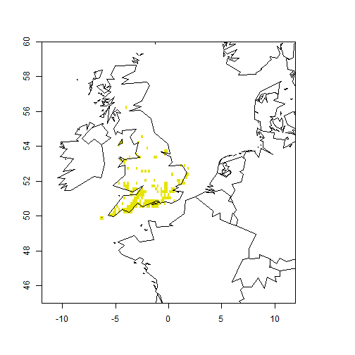

```r
plot(locs2ras, xlim = c(-10, 10), ylim = c(45, 60), legend = F)
data(wrld_simpl)
plot(wrld_simpl, add = T)
```

### Changing raster resolution

Use `aggregate` function:

```r
tmin1.lowres <- aggregate(tmin1.c, fact = 2, fun = mean)
tmin1.lowres
```

```
## class       : RasterLayer
## dimensions  : 60, 60, 3600  (nrow, ncol, ncell)
## resolution  : 0.3333, 0.3333  (x, y)
## extent      : -10, 10, 30, 50  (xmin, xmax, ymin, ymax)
## coord. ref. : +proj=longlat +ellps=WGS84 +datum=WGS84 +towgs84=0,0,0
## data source : in memory
## names       : tmin1
## values      : -10.57, 10.1  (min, max)
```

```r
tmin1.c  # compare
```

```
## class       : RasterLayer
## dimensions  : 120, 120, 14400  (nrow, ncol, ncell)
## resolution  : 0.1667, 0.1667  (x, y)
## extent      : -10, 10, 30, 50  (xmin, xmax, ymin, ymax)
## coord. ref. : +proj=longlat +ellps=WGS84 +datum=WGS84 +towgs84=0,0,0
## data source : in memory
## names       : tmin1
## values      : -12.3, 10.3  (min, max)
```

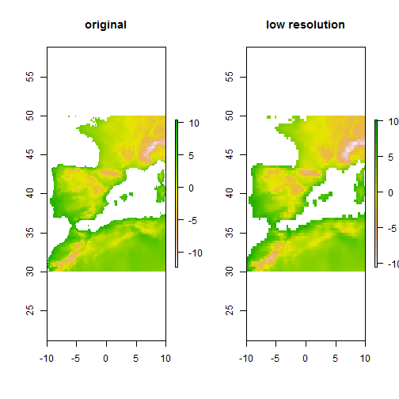

```r
par(mfcol = c(1, 2))
plot(tmin1.c, main = "original")
plot(tmin1.lowres, main = "low resolution")
```

### Spline interpolation

```r
xy <- data.frame(xyFromCell(tmin1.lowres, 1:ncell(tmin1.lowres)))  # get raster cell coordinates
head(xy)
```

```
##        x     y
## 1 -9.833 49.83
## 2 -9.500 49.83
## 3 -9.167 49.83
## 4 -8.833 49.83
## 5 -8.500 49.83
## 6 -8.167 49.83
```

```r
vals <- getValues(tmin1.lowres)
library(fields)
spline <- Tps(xy, vals)  # thin plate spline
intras <- interpolate(tmin1.c, spline)
intras  # note new resolution
```

```
## class       : RasterLayer
## dimensions  : 120, 120, 14400  (nrow, ncol, ncell)
## resolution  : 0.1667, 0.1667  (x, y)
## extent      : -10, 10, 30, 50  (xmin, xmax, ymin, ymax)
## coord. ref. : +proj=longlat +ellps=WGS84 +datum=WGS84 +towgs84=0,0,0
## data source : in memory
## names       : layer
## values      : -10.43, 13.16  (min, max)
```

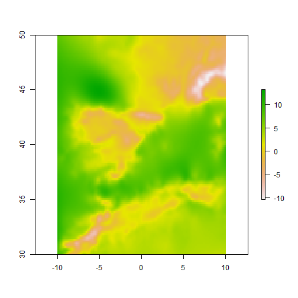

```r
plot(intras)
```

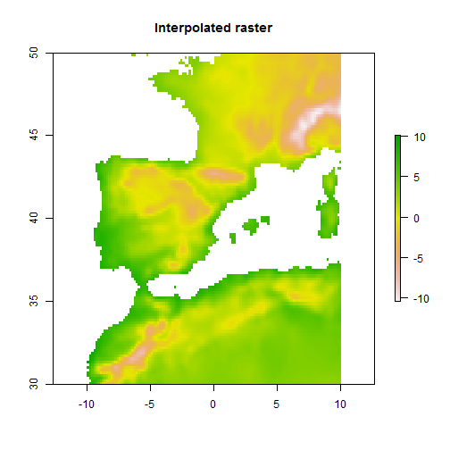

```r
intras <- mask(intras, tmin1.c)  # mask to land areas only
plot(intras)
title("Interpolated raster")
```

### Setting all rasters to the same extent, projection and resolution all in one

See `spatial_sync_raster` function from `spatial.tools` package.

### Elevations, slope, aspect, etc

Download elevation data from internet:

```r
elevation <- getData("alt", country = "ESP")
```

Some quick maps:

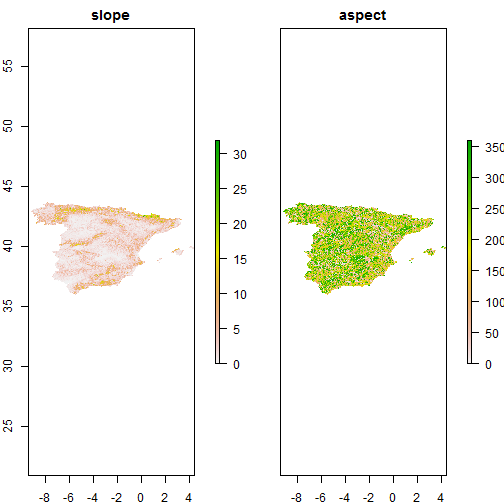

```r
x <- terrain(elevation, opt = c("slope", "aspect"), unit = "degrees")
plot(x)
```

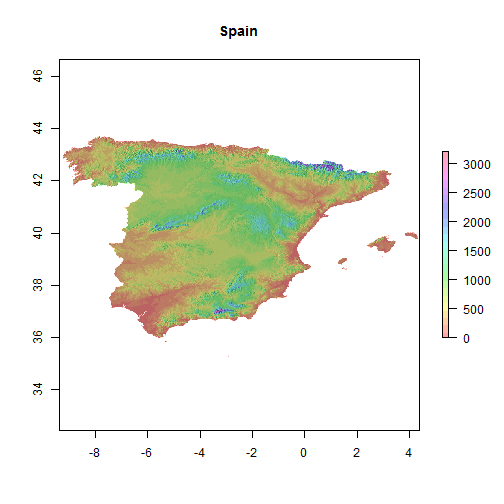

```r
slope <- terrain(elevation, opt = "slope")
aspect <- terrain(elevation, opt = "aspect")
hill <- hillShade(slope, aspect, 40, 270)
plot(hill, col = grey(0:100/100), legend = FALSE, main = "Spain")
plot(elevation, col = rainbow(25, alpha = 0.35), add = TRUE)
```

### Saving and exporting raster data

Saving raster to file:

```r
writeRaster(tmin1.c, filename = "tmin1.c.grd")
```

```
## class       : RasterLayer
## dimensions  : 120, 120, 14400  (nrow, ncol, ncell)
## resolution  : 0.1667, 0.1667  (x, y)
## extent      : -10, 10, 30, 50  (xmin, xmax, ymin, ymax)
## coord. ref. : +proj=longlat +ellps=WGS84 +datum=WGS84 +towgs84=0,0,0
## data source : C:\Users\FRS\Dropbox\R.scripts\my.Rcode\R-GIS tutorial\tmin1.c.grd
## names       : tmin1
## values      : -12.3, 10.3  (min, max)
```

```r
writeRaster(tmin.all.c, filename = "tmin.all.grd")
```

```
## class       : RasterBrick
## dimensions  : 120, 120, 14400, 12  (nrow, ncol, ncell, nlayers)
## resolution  : 0.1667, 0.1667  (x, y)
## extent      : -10, 10, 30, 50  (xmin, xmax, ymin, ymax)
## coord. ref. : +proj=longlat +ellps=WGS84 +datum=WGS84 +towgs84=0,0,0
## data source : C:\Users\FRS\Dropbox\R.scripts\my.Rcode\R-GIS tutorial\tmin.all.grd
## names       : tmin1, tmin2, tmin3, tmin4, tmin5, tmin6, tmin7, tmin8, tmin9, tmin10, tmin11, tmin12
## min values  : -12.3, -12.5, -10.8,  -8.6,  -4.2,  -0.8,   1.8,   1.6,  -0.1,   -3.3,   -8.1,  -10.8
## max values  :  10.3,  10.8,  12.5,  14.5,  19.7,  24.7,  27.6,  26.7,  22.9,   16.9,   13.7,   11.3
```

`writeRaster` can export to many different file types, see help.

Exporting to KML (Google Earth)

```r
tmin1.c <- raster(tmin.all.c, 1)
KML(tmin1.c, file = "tmin1.kml")
KML(tmin.all.c)  # can export multiple layers
```

Back to Contents

# 5. SPATIAL STATISTICS (just a glance)

### Point pattern analysis

Some useful packages:

```r
library(spatial)
library(spatstat)
library(spatgraphs)
library(ecespa)  # ecological focus
```

See [CRAN Spatial Task View](http://cran.r-project.org/web/views/Spatial.html).

Let's do a quick example with Ripley's K function:

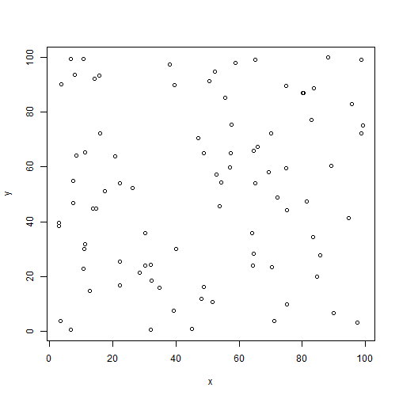

```r
data(fig1)
plot(fig1)  # point pattern
```

```r
data(Helianthemum)
cosa12 <- K1K2(Helianthemum, j = "deadpl", i = "survpl", r = seq(0, 200, le = 201),
    nsim = 99, nrank = 1, correction = "isotropic")
```

[output not shown]

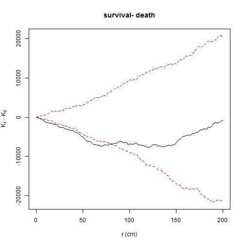

```
##       lty col   key         label
## lo      2   2    lo         lo(r)
## K1-K2   1   1 K1-K2 K1(r) - K2(r)
## hi      2   2    hi         hi(r)
##                                                                               meaning
## lo                                            lower pointwise envelope of simulations
## K1-K2 differences of  Ripley isotropic correction estimate of expression(K[1] - K[2])
## hi                                            upper pointwise envelope of simulations
```

```r
plot(cosa12$k1k2, lty = c(2, 1, 2), col = c(2, 1, 2), xlim = c(0, 200), main = "survival- death",
    ylab = expression(K[1] - K[2]), legend = FALSE)
```

### Geostatistics

Some useful packages:

```r
library(gstat)
library(geoR)
library(akima)  # for spline interpolation
library(spdep)  # dealing with spatial dependence
```

See [CRAN Spatial Task View](http://cran.r-project.org/web/views/Spatial.html).

Back to Contents

# 6. INTERACTING WITH OTHER GIS

```r
library(spgrass6)  # GRASS
library(RPyGeo)  # ArcGis (Python)
library(RSAGA)  # SAGA
library(spsextante)  # Sextante
```

Back to Contents

# 7. OTHER USEFUL PACKAGES

```r
library(Metadata)  # automatically collates data from online GIS datasets (land cover, pop density, etc) for a given set of coordinates

# library(GeoXp) # Interactive exploratory spatial data analysis
example(columbus)
histomap(columbus, "CRIME")

library(maptools)
# readGPS

library(rangeMapper)  # plotting species distributions, richness and traits


# Species Distribution Modelling
library(dismo)
library(biomod2)
library(SDMTools)

library(BioCalc)  # computes 19 bioclimatic variables from monthly climatic values (tmin, tmax, prec)
```

Back to Contents

# 8. TO LEARN MORE

- [ASDAR book](http://www.asdar-book.org/)
- Packages help and vignettes, especially

  http://cran.r-project.org/web/packages/raster/vignettes/Raster.pdf  
  http://cran.r-project.org/web/packages/dismo/vignettes/sdm.pdf  
  http://cran.r-project.org/web/packages/sp/vignettes/sp.pdf
- [CRAN Task View: Analysis of Spatial Data](http://cran.r-project.org/web/views/Spatial.html)
- [Introduction to Spatial Data and ggplot2](http://rpubs.com/RobinLovelace/intro-spatial)
- [R spatial tips](http://spatial.ly/category/r-spatial-data-hints/)
- [R wiki: tips for spatial data](http://rwiki.sciviews.org/doku.php?id=tips:spatial-data&s=spatial)
- [Spatial analysis in R](http://www.maths.lancs.ac.uk/%7Erowlings/Teaching/Sheffield2013/index.html)
- [Displaying time series, spatial and space-time data with R](http://oscarperpinan.github.io/spacetime-vis/)
- [Notes on Spatial Data Operations in R](https://dl.dropboxusercontent.com/u/9577903/broomspatial.pdf)
- [Analysing spatial point patterns in R](http://www.csiro.au/resources/pf16h)
- [Spatial data in R](http://science.nature.nps.gov/im/datamgmt/statistics/r/advanced/Spatial.cfm)
- [NCEAS Geospatial use cases](http://www.nceas.ucsb.edu/scicomp/usecases)
- [Spatial Analyst](http://spatial-analyst.net)
- [Making maps with R](http://www.molecularecologist.com/2012/09/making-maps-with-r/)
- [The Visual Raster Cheat Sheet](http://www.rpubs.com/etiennebr/visualraster)
- [R-SIG-Geo mailing list](https://stat.ethz.ch/mailman/listinfo/R-SIG-Geo)

Back to Contents